# Going to France: Wrapping up for the trip

Plane ticket, CVEC, money, COVID tests, and everything for the trip

french bureaucracy

going to France

Published

September 29, 2021

After getting my French Visa and being accepted into a Student Residence, I had to prepare for the trip.

# CVEC

The [CVEC](https://cvec.etudiant.gouv.fr/) (*Contribution de vie étudiante et de Campus*) is the French version of a tuition fee. It is payed for a whole year.

> Erasmus Mundus students do not have to pay the CVEC

Erasmus Mundus students need to get a certificate saying that they are excempt of paying the CVEC. Here’s how I got mine.

In the website [MesServices Étudiant](https://www.messervices.etudiant.gouv.fr/) there is a CVEC field:

[figure not shown]

Pressing here will redirect you to the [CVEC website](https://cvec.etudiant.gouv.fr/), which is also available in English.

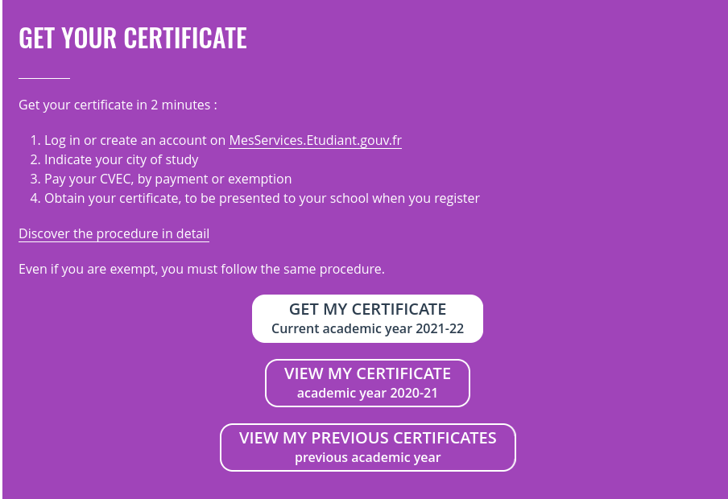

I followed the instructions, but when I was asked to prove that I was excempted from paying, I could not find a `Erasmus Mundus` option.

What I did was select `Bourse du gouvernement français` (Scholarship from the French government), and uploaded the admission letter from the Université de Lorraine.

One week later the exemption certificate was available for download.

> The exemption certificate is needed for registration at the Université de Lorraine

# Plane ticket to Paris

I waited until having both my French visa and being accepted into a Student Residence to buy my plane ticket.

Those procedures finished one month before my departure, which increased the price of the plane ticket for me. Additionally, due to COVID, there were very few flights available.

Also due to COVID, the idea of making transfers was very unattractive, because each country had their own conditions for entry. Thus, I had to look up direct flights.

I ended up buying a 1000 USD plane ticket for an AirFrance flight from Lima to Paris.

Withouth a doubt, under pre-COVID conditions this would not have been so expensive.

My flight arrived at [Charles de Gaulle Airport](https://en.wikipedia.org/wiki/Charles_de_Gaulle_Airport) (CDG), which is **huge**. I needed to keep this in mind when buying tickets to get to Nancy.

# Tickets to Nancy

The [SNCF](https://www.sncf-connect.com/) is the French public railway company.

In their website, also available in English, I bought my tickets to Nancy.

I bought tickets for the Highspeed train TGV (*train à Grande Vitesse*) and then transferred to a bus to Nancy, all for **70 €**

My schedule was the following: - A TGV from CDG airport to the Lorraine-TGV station (between Nancy and Metz), around 3 hours.

- A bus from the Lorraine-TGV station to the Nancy *Gare* (Nancy main station), around half an hour.

According to that schedule, I would arrive in Nancy around 5pm.

The Lorraine TGV:

[interactive chart not shown]

Nancy Gare:

[interactive chart not shown]

# Documents required at the Airport

Because of COVID, to enter France it was not enough to have a French Visa. Flights were restricted to those “with a good reason for travelling” and that were not at risk of having COVID.

The (printed) documents required to get into the flight were:

- A PCR test with negative result done in the last 48 hours. I got it in a lab for around 60 USD.
- A sworn declaration of having no COVID symptoms.
- A sworn declaration saying I had good reasons for travelling (I selected “Studies”).

These two last documents (in French!) could be downloaded from a website from the French Government, by Googling “entrance to France for foreigners COVID”.

# Money exchange

Weeks before travelling, I started exchanging my money into Euros. I did it in medium sized batches of money, so I waited for moments with good exchange rates to exchange each batch.

I found one bank in my country that made international transfers in Euros at a flat rate: it was the same price independent of the amount of Euros sent!

However, I did not have a European bank account. Since I already had a trusted friend living in the European Union, me and them talked about the possibility of a transfer. I sent them the money in two batches, and each transfer took approximately four days to transfer.

Additionally, since I did not know how long creating a bank account would take, I took a bunch of cash with me (around 2000 €).

[figure not shown]

# Saying farewell

Most of the times when I was not doing any bureaucracy, I took to say goodbye to my friends in person.

The uncertainty of not knowing when (and if) I would see them again was heavy.

With all its faults, online communication helps at least a little.

I got to see people I had not seen in years.

Good times.

Now the big day was getting closer.

[video not shown]